# Normalise for IC50 with K-Clustering: Visualisation

Kate Chiang

2024-05-17

This document allows visualisation of the use of k-clustering to select the best mean for normalising neutralisation data and account for dodgy control values.

#Download Packages

```r
library(ggplot2) #to make ggplot
library(tidyverse)
library(tidyr)
library(dplyr)
library(Ckmeans.1d.dp) #for k-clustering
```

# 1 Setting up

```r
input_file <- here::here("Validation/anomaly_detection/example1kcv2.xlsx") #CHANGE to example file in your directory for troubleshooting
input_directory = here::here("Validation/anomaly_detection/") #CHANGE this to directory of input .xlsx data files
```

```r
rotate_by <- 0 # clockwise degrees, multiples of 90, useful when doing 12 fold dilutions.
control_neg_column <- c(1) # default negative control column is on first column from the left
control_pos_column <- c(2) # default positive control column is on second column from the left
```

Getting the filenames from our directory of anomalous data

```r
anomaly_detection_files <- Sys.glob(paste0(
  paste0(input_directory,"/*.xlsx")) # find all .xlsx file in input directory
)
anomaly_detection_files
```

```
## [1] "/Users/katie/Documents/GitHub/Visualise/Validation/anomaly_detection//example1kc.xlsx"
## [2] "/Users/katie/Documents/GitHub/Visualise/Validation/anomaly_detection//example1kcv2.xlsx"
```

# 2 Example case: examplekcv2

Examplekcv2 contains anomalously low values in the positive control column that are not ideal for normalisation. Although the majority of the values are low, the positive control values can be clustered into two groups with the higher average being better for normalisation - as long as the cluster used in normalisation contains at least three values.

```r
df <- NormaliseForIC50::read_promega_plate_excel(input_promega_excel_file_path = input_file)
df
```

```
##   neg    pos sample one sample one.1 sample two     NA sample three
## A  90 376100     182200       229100     275900 186500           80
## B  80  27750     289200       292000     100900 245400          100
## C 100  28720     288400       292000     278800 277700          380
## D 110 301300     309500       301100     304800 313300        24090
## E  50  28060     293000       286400     309400 292500        99030
## F  90  27200     266000       289600     303000 309200       175700
## G 100  25120     295100       286500     311100 283200       244100
## H  50 348100     350900       345000     386400 364800       343600
##   sample three.1      9     10     11     12
## A             90 133200 143600  55510  96660
## B            110 266000 269900 259500 298000
## C            830 291200 293900 275200 327900
## D          27390 314900 289400 314200 397400
## E         119800 300700 322300 293400 360300
## F         203000 302600 294500 293000 379000
## G         239600 287200 307500 295000 372400
## H         351700 360300 332200 350300 368300
```

# 3 Clean dataset

Isolate the positive and negative control values and the three largest and three smallest values from each sample column

```r
#'Use get_top_bottom function to isolate top 3 and bottom 3 values
get_top_bottom <- function(column) {
  top_values <- sort(column, decreasing = TRUE)[1:3]
  bottom_values <- sort(column)[1:3]
  return(c(top_values, bottom_values))
}
top_bottom_values <- lapply(df[c(3:12)], get_top_bottom) #Apply get_top_bottom function
top_bottom_df <- as.data.frame(top_bottom_values) #Create data frame
df.vis <- top_bottom_df %>% gather(key=y, value=x)
data_min_max <- df.vis %>% #Rearrange to get three columns with data labeled as 'min' or 'max'
  arrange(x) %>%
  group_by(y) %>%
  mutate(Label = case_when(
      row_number() <= 3 ~ "min",
      row_number() > n() - 3 ~ "max",
      TRUE ~ NA_character_
    ))

#'Isolate and cluster positive control values (The third column refers to which cluster the value belongs to)
#'Ensure that the third column "Label" is a character
control_pos_values <- df[c(2)] %>% gather(key=y, value=x)
poscontrolmeans <- Ckmeans.1d.dp::Ckmeans.1d.dp(as.numeric(unlist(df[c(2)])))
control_pos_values$Label <- poscontrolmeans$cluster
control_pos_values<-transform(control_pos_values, Label = as.character(Label)) #"Label" column is denoted as <character>

#'Isolate and cluster negative control values (The third column refers to which cluster the value belongs to)
control_neg_values <- df[c(1)] %>% gather(key=y, value=x)
negcontrolmeans <- Ckmeans.1d.dp::Ckmeans.1d.dp(as.numeric(unlist(df[c(1)])))
control_neg_values$Label <- negcontrolmeans$cluster
control_neg_values <- transform(control_neg_values, Label = as.character(Label)) #"Label" column is denoted as <character>
```

# 4 K-clustering

Select the cluster mean from the positive and negative control that is closest to the average of the sample maximum and sample minimum values, respectively. A warning will be thrown if none of the k-clusters have at least 3 values.

```r
source(here::here("R/k_clustering.R"))
source(here::here("R/normalise_plate.R"))
source(here::here("R/mean_without_outliers.R"))
#exclude positive and negative control columns
  df.values<-df[,-c(control_neg_column,control_pos_column)]

  # Throw warning
  check_max(df.values,filename = filename) #warning if last three row values are not the largest in the column
  check_min(df.values,filename = filename) #warning if first three row values are not the smallest in the column
  lim <- data.frame(
    lower_lim = apply(df.values, MARGIN = 2, min),
    upper_im = apply(df.values, MARGIN = 2, max)
  )
```

Isolate suitable positive and negative control clusters

```r
control.neg <- k_clustering(unlist(df[,control_neg_column]), lim$lower_lim, type = "negative", na.rm=TRUE)
```

```
## 2negativeclusters: sized2,6
```

```r
control.pos <- k_clustering(unlist(df[,control_pos_column]), lim$upper_im, type = "positive", na.rm=TRUE)
```

```
## 2positiveclusters: sized5,3
```

# 5 Plot

Combine control and sample data into dataset containing samples, values, and labels.

```r
#'Combine labeled control and sample graphs
df.visualize <- control_neg_values %>%
  bind_rows(control_pos_values)%>%
  bind_rows(data_min_max)
```

The plot shows boxplots for the minimum and maximum three values for each sample. Boxplots in the pos and neg control columns represent the identified clusters. An hline() is created for the mean of a select cluster generated via the k-clustering function. From the positive control, the “Positive Control Cluster Mean” is the mean of the cluster that is closest to the average of the sample maximums (highest values on the “max” boxplots). From the negative control, the “Negative Control Cluster Mean” is the mean of the cluster that is closest to the average of the sample minimums (lowest values on the “min” boxplots).

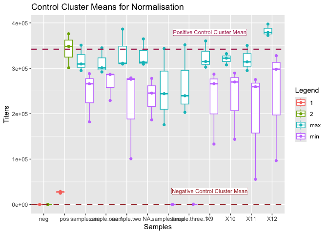

```r
ggplot(df.visualize, suppressWarnings(aes(x=df.visualize$y, y=df.visualize$x, color=Label)))+
         labs(title = "Control Cluster Means for Normalisation",
              x="Samples", y="Titers", color = "Legend")+
         geom_boxplot(position = position_dodge(0.8))+
         geom_jitter(position = position_dodge(0.8))+
         scale_x_discrete(limits=c("neg", "pos", "sample.one", "sample.one.1", "sample.two", "NA.", "sample.three", "sample.three.1", "X9", "X10", "X11","X12"))+
         geom_hline(yintercept = control.pos, color="maroon", lty="dashed", lwd=1)+
         geom_hline(yintercept = control.neg, color="brown", lty="dashed", lwd=1)+
  geom_label(label="Positive Control Cluster Mean",
             x = "X9",
             y = 380000,
             label.padding = unit(0.01, "lines"),
             label.size = 0.05,
             color = "maroon",
             size = 3)+
  geom_label(label="Negative Control Cluster Mean",
             x = "X9",
             y = 30000,
             label.padding = unit(0.01, "lines"),
             label.size = 0.05,
             color = "brown",
             size = 3)
```

Compared to simple means, the cluster mean appears to work better for normalisation of widely varying control data since it selects a mean that is closest to the average maximum and minimum samples values. The hline for the positive control simple mean is much lower and not as close to the sample maximums as the selected cluster mean.

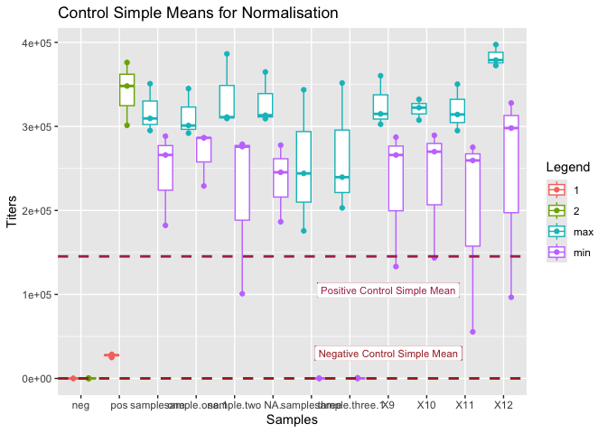

```r
ggplot(df.visualize, suppressWarnings(aes(x=df.visualize$y, y=df.visualize$x, color=Label)))+
         labs(title = "Control Simple Means for Normalisation",
              x="Samples", y="Titers", color = "Legend")+
         geom_boxplot(position = position_dodge(0.8))+
         geom_jitter(position = position_dodge(0.8))+
         scale_x_discrete(limits=c("neg", "pos", "sample.one", "sample.one.1", "sample.two", "NA.", "sample.three", "sample.three.1", "X9", "X10", "X11","X12"))+
         geom_hline(yintercept = mean(unlist(df[,control_pos_column]),na.rm=TRUE), color="maroon", lty="dashed", lwd=1)+
         geom_hline(yintercept = mean(unlist(df[,control_neg_column]),na.rm=TRUE), color="brown", lty="dashed", lwd=1)+
  geom_label(label="Positive Control Simple Mean",
             x = "X9",
             y = 105000,
             label.padding = unit(0.3, "lines"),
             label.size = 0.05,
             color = "maroon",
             size = 3)+
  geom_label(label="Negative Control Simple Mean",
             x = "X9",
             y = 30000,
             label.padding = unit(0.3, "lines"),
             label.size = 0.05,
             color = "brown",
             size = 3)
```